# ridge-lasso-elastic-net-diabetes-dataset

## **Table of contents:**

**1. Intuition**  
1.1 What is Regularization  
1.2 Ridge Regression  
1.3 Lasso Regression  
1.4 Elastic Net Regression  
1.5 Key differences  
1.6 Criteria to choose regularization method

## 1.1 What is Regularization

Getting a good accuracy score isn't always pleasant to a data scientist specially when he gets a good training accuracy along with a poor test accuracy. Though this type of model can predict the training set very well, but it can't perform well for the test as well as new dataset. This type of situation or model is called **Overfitting**. So how can we solved this problem?

Here comes up **Regularizaton** to solve this problem. So in short, we can say that Regularizaton is the process to prevent a model to be overfitted.

But how? Regularization can be carried out by **Ridge Regression**, **Lasso Regression** and **Elastic Net Regression**. We will try to learn how these regression work and reduce the risk of overfitting throughout this kernel.

## 1.2 Ridge Regression

It's also called L2 regularization. It shrinks the coefficients by adding a penalty to the least squares.

**Ridge Regression penalty = lambda1 x square of the magnitude of the coefficients**

By shrinking the coefficients Ridge Regession reduces the model complexity and multi-collinearity. But it keeps all the variables.

## 1.3 Lasso Regression

It's also called L1 regularization. It shrinks the coefficients by adding a penalty to the least squares.

**Lasso Regression penalty = lambda2 x |the magnitude of the coefficients|**

By shrinking the coefficients Lasso Regession also reduces the model complexity and multi-collinearity like Ridge Regression. But in Lasso Regression, the coefficients of less important variables get multiplied by zero and removed.

## 1.4 Elastic Net Regression

Elastic Net is the combination of Ridge and Lasso Regression. It has both Ridge Regression penalty and Lasso Regression penalty in it's own penalty.

**Elastic Net Regression penalty = lambda1 x square of the magnitude of the coefficients + lambda2 x |the magnitude of the coefficients|**

When,  
lambda1 = lambda2 = 0 - Elastic Net becomes least square parameter estimates  
lambda1 > 0 and lambda2 = 0 - Ridge Regression  
lambda1 = 0 and lambda2 > 0 - Lasso Regression  
lambda1 >0 and lambda2 > 0 - Elastic Net Regression

## 1.5 Key differences

Ridge and Lasso Regression are almost same. But the only key difference they have is Ridge Regression doesn't remove any features while the features with less importance is removed by Lasso Regression.

## 1.6 Criteria to choose regularization method

**Ridge Regression**

1. When all the features you have are important to your model
2. When you don't want to do feature selection as well as feature removing

**Lasso Regression**

1. When you have too many features
2. And you know some of them don't have any significance to your model
3. When you want to remove the features with less importance

**Elastic Net Regression**

1. When you don't know whether all the features have significance or not
2. when there are strong correlations between features

## 2.1 Importing necessary modules along with dataset

##### Modules

```python
import pandas as pd
import numpy as np
import matplotlib.pyplot as plt
%matplotlib inline

from sklearn.model_selection import train_test_split
from sklearn.preprocessing import StandardScaler
from sklearn.linear_model import LinearRegression, Ridge, Lasso, ElasticNet
from sklearn.metrics import r2_score
from sklearn.model_selection import cross_val_score, GridSearchCV
```

[output not shown]

##### To avoid unwanted warnings

```python
import warnings

warnings.filterwarnings('ignore', category = DeprecationWarning)
from warnings import filterwarnings
filterwarnings('ignore')
```

##### Load the dataset

```python
from sklearn.datasets import load_diabetes
df = load_diabetes()
df
```

[output not shown]

[output cut: 14 more lines]

```
 'frame': None,
 'DESCR': '.. _diabetes_dataset:\n\nDiabetes dataset\n----------------\n\nTen baseline variables, age, sex, body mass index, average blood\npressure, and six blood serum measurements were obtained for each of n =\n442 diabetes patients, as well as the response of interest, a\nquantitative measure of…
 'feature_names': ['age',
  'sex',
  'bmi',
  'bp',
  's1',
  's2',
  's3',
  's4',
  's5',
  's6'],
 'data_filename': 'diabetes_data_raw.csv.gz',
 'target_filename': 'diabetes_target.csv.gz',
 'data_module': 'sklearn.datasets.data'}
```

```python
data=pd.DataFrame(df["data"] , columns=df['feature_names'])
data["target"]=df["target"]
data
```

|  | age | sex | bmi | bp | s1 | s2 | s3 | s4 | s5 | s6 | target |
| --- | --- | --- | --- | --- | --- | --- | --- | --- | --- | --- | --- |
| 0 | 0.038076 | 0.050680 | 0.061696 | 0.021872 | -0.044223 | -0.034821 | -0.043401 | -0.002592 | 0.019907 | -0.017646 | 151.0 |
| 1 | -0.001882 | -0.044642 | -0.051474 | -0.026328 | -0.008449 | -0.019163 | 0.074412 | -0.039493 | -0.068332 | -0.092204 | 75.0 |
| 2 | 0.085299 | 0.050680 | 0.044451 | -0.005670 | -0.045599 | -0.034194 | -0.032356 | -0.002592 | 0.002861 | -0.025930 | 141.0 |
| 3 | -0.089063 | -0.044642 | -0.011595 | -0.036656 | 0.012191 | 0.024991 | -0.036038 | 0.034309 | 0.022688 | -0.009362 | 206.0 |
| 4 | 0.005383 | -0.044642 | -0.036385 | 0.021872 | 0.003935 | 0.015596 | 0.008142 | -0.002592 | -0.031988 | -0.046641 | 135.0 |
| ... | ... | ... | ... | ... | ... | ... | ... | ... | ... | ... | ... |
| 437 | 0.041708 | 0.050680 | 0.019662 | 0.059744 | -0.005697 | -0.002566 | -0.028674 | -0.002592 | 0.031193 | 0.007207 | 178.0 |
| 438 | -0.005515 | 0.050680 | -0.015906 | -0.067642 | 0.049341 | 0.079165 | -0.028674 | 0.034309 | -0.018114 | 0.044485 | 104.0 |
| 439 | 0.041708 | 0.050680 | -0.015906 | 0.017293 | -0.037344 | -0.013840 | -0.024993 | -0.011080 | -0.046883 | 0.015491 | 132.0 |
| 440 | -0.045472 | -0.044642 | 0.039062 | 0.001215 | 0.016318 | 0.015283 | -0.028674 | 0.026560 | 0.044529 | -0.025930 | 220.0 |
| 441 | -0.045472 | -0.044642 | -0.073030 | -0.081413 | 0.083740 | 0.027809 | 0.173816 | -0.039493 | -0.004222 | 0.003064 | 57.0 |

442 rows × 11 columns

```python
# df['data']
```

```python
# data=pd.DataFrame(df['data'],columns=df['feature_names'])
# data['target']=df['target']
# data
```

## 2.2 Data processing

##### Splitting into X and y

```python
X = data.data
y = data.target
```

##### Scaling

```python
scaler = StandardScaler()
X = scaler.fit_transform(X)
```

##### Spliting into train and test set

```python
X_train, X_test, y_train, y_test = train_test_split(X, y, test_size = 0.2, random_state = 0)
```

## 2.3 Linear Regression Model

```python
lr = LinearRegression()

# Train the model
model_lr = lr.fit(X_train, y_train)

# Prediction
y_pred_train_lr = lr.predict(X_train)
y_pred_test_lr = lr.predict(X_test)

# Accuracy Score
print('Training accuracy : {}\n'.format(r2_score(y_train, y_pred_train_lr)))
print('Testing accuracy : {}\n'.format(r2_score(y_test, y_pred_test_lr)))
```

```
Training accuracy : 0.5539250081377072

Testing accuracy : 0.33223321731061817
```

##### Mean Squared Error

```python
mse=cross_val_score(lr, X, y, scoring='neg_mean_squared_error',cv=5)
mean_mse=np.mean(mse)
print(-(mean_mse).round(5))
```

```
2993.08131
```

##### Horizontal Barplot for observing the significance of each features

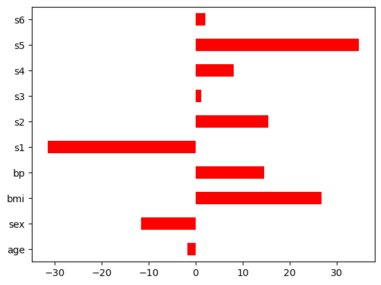

```python
coefs = pd.Series(lr.coef_, index = df.feature_names)
coefs.plot(kind = 'barh', cmap = 'autumn')
plt.show()
```

## 2.4 Ridge Regression

```python
ridge1 = Ridge()

# Fit the model
model_ridge1 = ridge1.fit(X_train, y_train)

# Prediction
y_pred_train_ridge1 = ridge1.predict(X_train)
y_pred_test_ridge1 = ridge1.predict(X_test)

# Accuracy Score
print('Training accuracy : {}\n'.format(r2_score(y_train, y_pred_train_ridge1)))
print('Testing accuracy : {}'.format(r2_score(y_test, y_pred_test_ridge1)))
```

```
Training accuracy : 0.5537818217533377

Testing accuracy : 0.33106342873379824
```

##### Mean Squared Error

```python
mse1 = cross_val_score(ridge1, X, y, scoring = 'neg_mean_squared_error',cv=5)
mean_mse1 = np.mean(mse1)
print(-(mean_mse1).round(5))
```

```
2993.63929
```

##### Horizontal Barplot for observing the significance of each features

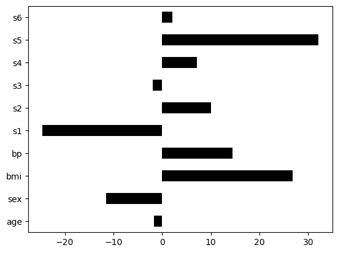

```python
coefs_ridge1 = pd.Series(ridge1.coef_, index = df.feature_names)
coefs_ridge1.plot(kind = 'barh', cmap = 'gist_heat')
plt.show()
```

# 2.5 Ridge Regression with GridSearchCV

```python
ridge2 = Ridge()

parameters = {'alpha' : [1e-15, 1e-10, 1e-8, 1e-3, 1e-2, 0.9, 0.8, 0.7, 0.5, 1, 5, 10, 20, 30, 35, 40, 45, 50, 55, 100]}

ridge_regressor = GridSearchCV(ridge2, parameters, scoring='neg_mean_squared_error', cv= 10)

ridge_regressor.fit(X_train, y_train)
```

```
GridSearchCV(cv=10, estimator=Ridge(),
             param_grid={'alpha': [1e-15, 1e-10, 1e-08, 0.001, 0.01, 0.9, 0.8,
                                   0.7, 0.5, 1, 5, 10, 20, 30, 35, 40, 45, 50,
                                   55, 100]},
             scoring='neg_mean_squared_error')
```

##### Best parameter and best score

```python
print(ridge_regressor.best_params_)
print(-(ridge_regressor.best_score_))
```

```
{'alpha': 20}
2892.7189197090966
```

```python
# Prediction
y_train_pred_ridg2 = ridge_regressor.predict(X_train)
y_test_pred_ridg2 = ridge_regressor.predict(X_test)

# Accuracy Score
print('Training accuracy : {}\n'.format(r2_score(y_train, y_train_pred_ridg2)))
print('Testing accuracy : {}'.format(r2_score(y_test, y_test_pred_ridg2)))
```

```
Training accuracy : 0.5512584643633347

Testing accuracy : 0.33448861675250485
```

##### Mean Squared Error

```python
mse2 = cross_val_score(ridge_regressor, X, y, scoring = 'neg_mean_squared_error',cv=5)
mean_mse2 = np.mean(mse2)
print(-(mean_mse2).round(5))
```

```
3018.53218
```

## 2.6 Lasso Regression

```python
lasso1 = Lasso()

# Fit the model
model_lasso1 = lasso1.fit(X_train, y_train)

# Prediction
y_pred_train_lasso1 = lasso1.predict(X_train)
y_pred_test_lasso1 = lasso1.predict(X_test)

# Accuracy Score
print('Training accuracy : {}\n'.format(r2_score(y_train, y_pred_train_lasso1)))
print('Testing accuracy : {}'.format(r2_score(y_test, y_pred_test_lasso1)))
```

```
Training accuracy : 0.5504972050568253

Testing accuracy : 0.3343586610242273
```

##### Mean Squared Error

```python
mse3 = cross_val_score(lasso1, X, y, scoring = 'neg_mean_squared_error',cv=5)
mean_mse3 = np.mean(mse3)
print(-(mean_mse3).round(5))
```

```
2994.07544
```

##### Horizontal Barplot for observing the significance of each features

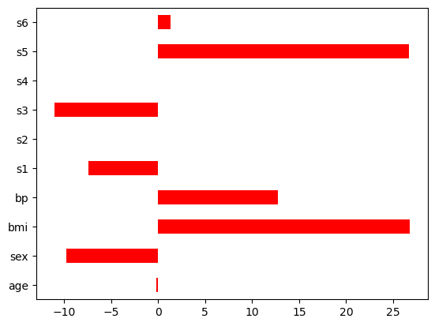

```python
coefs_lasso1 = pd.Series(lasso1.coef_, index = df.feature_names)
coefs_lasso1.plot(kind = 'barh', cmap = 'autumn')
plt.show()
```

## 2.7 Lasso Regression with GridSearchCV

```python
lasso2 = Lasso()

parameters = {'alpha' : [1e-15, 1e-10, 1e-8, 1e-3, 1e-2, 0.9, 0.8, 0.7, 0.5, 1, 5, 10, 20, 30, 35, 40, 45, 50, 55, 100]}

lasso_regressor = GridSearchCV(lasso2, parameters, scoring='neg_mean_squared_error', cv= 10)

lasso_regressor.fit(X_train, y_train)
```

```
GridSearchCV(cv=10, estimator=Lasso(),
             param_grid={'alpha': [1e-15, 1e-10, 1e-08, 0.001, 0.01, 0.9, 0.8,
                                   0.7, 0.5, 1, 5, 10, 20, 30, 35, 40, 45, 50,
                                   55, 100]},
             scoring='neg_mean_squared_error')
```

##### Best parameter and best score

```python
print(lasso_regressor.best_params_)
print(-(lasso_regressor.best_score_))
```

```
{'alpha': 1}
2889.3757155149165
```

##### Mean Squared Error

```python
mse4 = cross_val_score(lasso_regressor, X, y, scoring = 'neg_mean_squared_error',cv=5)
mean_mse4 = np.mean(mse4)
print(-(mean_mse4))
```

```
3006.739254277718
```

```python
# Prediction
y_train_pred_lasso2 = lasso_regressor.predict(X_train)
y_test_pred_lasso2 = lasso_regressor.predict(X_test)

# Accuracy Score
print('Training accuracy : {}\n'.format(r2_score(y_train, y_train_pred_lasso2)))
print('Testing accuracy : {}'.format(r2_score(y_test, y_test_pred_lasso2)))
```

```
Training accuracy : 0.5504972050568253

Testing accuracy : 0.3343586610242273
```

## 2.8 Elastic Net Regression

```python
enet1 = ElasticNet()

# Fit the model
model_enet1 = enet1.fit(X_train, y_train)

# Prediction
y_pred_train_enet1 = enet1.predict(X_train)
y_pred_test_enet1 = enet1.predict(X_test)

# Accuracy Score
print('Training accuracy : {}\n'.format(r2_score(y_train, y_pred_train_enet1).round(5)))
print('Testing accuracy : {}'.format(r2_score(y_test, y_pred_test_enet1).round(5)))
```

[output not shown]

##### Mean Squared Error

```python
mse5 = cross_val_score(enet1, X, y, scoring = 'neg_mean_squared_error',cv=5)
mean_mse5 = np.mean(mse5)
print(-(mean_mse5).round(5))
```

[output not shown]

##### Horizontal Barplot for observing the significance of each features

```python
coefs_enet1 = pd.Series(enet1.coef_, index = df.feature_names)
coefs_enet1.plot(kind = 'barh', cmap = 'autumn')
plt.show()
```

[output not shown]

## 2.9 Elastic Net Regression with GridSearchCV

```python
enet2 = ElasticNet()

parameters = {'alpha' : [1e-15, 1e-10, 1e-8, 1e-3, 1e-2, 0.9, 0.8, 0.7, 0.5, 1, 5, 10, 20, 30, 35, 40, 45, 50, 55, 100]}

enet_regressor = GridSearchCV(enet2, parameters, scoring='neg_mean_squared_error', cv= 10)

enet_regressor.fit(X_train, y_train)
```

```
GridSearchCV(cv=10, estimator=ElasticNet(),
             param_grid={'alpha': [1e-15, 1e-10, 1e-08, 0.001, 0.01, 0.9, 0.8,
                                   0.7, 0.5, 1, 5, 10, 20, 30, 35, 40, 45, 50,
                                   55, 100]},
             scoring='neg_mean_squared_error')
```

##### Best parameter and best score

```python
print(enet_regressor.best_params_)
print(-(enet_regressor.best_score_))
```

```
{'alpha': 0.01}
2895.3144383457957
```

##### Mean Squared Error

```python
mse5 = cross_val_score(enet_regressor, X, y, scoring = 'neg_mean_squared_error',cv=5)
mean_mse5 = np.mean(mse5)
print(-(mean_mse5))
```

```
2999.263548263404
```

```python
# Prediction
y_train_pred_enet2 = enet_regressor.predict(X_train)
y_test_pred_enet2 = enet_regressor.predict(X_test)

# Accuracy Score
print('Training accuracy : {}\n'.format(r2_score(y_train, y_train_pred_enet2)))
print('Testing accuracy : {}'.format(r2_score(y_test, y_test_pred_enet2)))
```

```
Training accuracy : 0.5535810907106399

Testing accuracy : 0.3304763097013216
```

# Conclusion

**Linear Regression**  
Training accuracy : 0.55393  
Testing accuracy : 0.33222

**Ridge Regression**  
Training accuracy : 0.55379  
Testing accuracy : 0.33105

**Ridge Regression with GridSearchCV**  
Training accuracy : 0.55126  
Testing accuracy : 0.33448

**Lasso Regression**  
Training accuracy : 0.5505  
Testing accuracy : 0.33435

**Lasso Regression with GridSearchCV**  
Training accuracy : 0.5505  
Testing accuracy : 0.33435

**Elastic Net Regression with GridSearchCV**  
Training accuracy : 0.55358  
Testing accuracy : 0.33047